# Cyclistic - Case study

Nitin Reddy M

2024-04-5

## Ask

### About

Cyclistic launched a successful bike-share program in Chicago in 2016, boasting a fleet of nearly 6,000 bikes across 692 stations. They offer flexible pricing plans catering to casual riders and annual members, with the latter proving to be more profitable. Marketing efforts now focus on converting casual riders into annual members, leveraging their existing awareness of the program. Moreno’s team aims to analyze historical bike trip data to identify trends and inform their conversion strategies.

### Key stakeholders

The key stakeholders for this project include:

- **Lily Moreno:** The director of marketing and your manager. Moreno is responsible for the development of campaigns and initiatives to promote the bike-share program. These may include email, social media, and other channels.
- **Cyclistic marketing analytics team:** A team of data analysts who are responsible for collecting, analyzing, and reporting data that helps guide Cyclistic marketing strategy.
- **Cyclistic executive team:** The notoriously detail-oriented executive team will decide whether to approve the recommended marketing program.

### Guiding question

This question will guide the future marketing program:

- How do annual members and casual riders use Cyclistic bikes differently?

### Business task

> Conduct an analysis of bike ride data to extract insights distinguishing between the behaviors of casual riders and subscribed members. Identify trends gleaned from this analysis to inform Cyclistic’s marketing strategy effectively.

## Prepare

### Data source

We will be using Cyclistic’s historical trip data to analyze and identify trends [Dataset](https://divvy-tripdata.s3.amazonaws.com/index.html). The data has been made available by Motivate International Inc. under this [license](https://divvybikes.com/data-license-agreement)

### Data Structure:

There are a total of 12 .csv files, each representing a month of the year 2023, containing this data.

### Data Credibility:

- The data is sourced directly from the Cyclistic database, ensuring its originality.
- It encompasses all necessary information for thorough analysis, indicating its comprehensiveness.
- Being from the year 2023, the data remains current and up-to-date.

## Process

### Why R and Tableau ?

Using R for data analysis provides powerful statistical and data manipulation capabilities, making it ideal for processing and analyzing large datasets, such as bike ride data. R’s extensive library ecosystem includes packages tailored for various analytical tasks, enabling in-depth exploration and visualization of the data.

Tableau, on the other hand, excels in creating interactive and visually appealing dashboards and visualizations. It allows for easy exploration and presentation of insights derived from the data analyzed in R.

### Importing data

Install and load necessary packages and libraries:

```r
library(tidyverse)
library(janitor)
library(lubridate)
library(dplyr)
```

Import the data sets

```r
df1 <- read_csv("202301-divvy-tripdata.csv")
df2 <- read_csv("202302-divvy-tripdata.csv")
df3 <- read_csv("202303-divvy-tripdata.csv")
df4 <- read_csv("202304-divvy-tripdata.csv")
df5 <- read_csv("202305-divvy-tripdata.csv")
df6 <- read_csv("202306-divvy-tripdata.csv")
df7 <- read_csv("202307-divvy-tripdata.csv")
df8 <- read_csv("202308-divvy-tripdata.csv")
df9 <- read_csv("202309-divvy-tripdata.csv")
df10 <- read_csv("202310-divvy-tripdata.csv")
df11 <- read_csv("202311-divvy-tripdata.csv")
df12 <- read_csv("202312-divvy-tripdata.csv")
```

Check the structure of the data

```r
str(df1)
str(df2)
str(df3)
str(df4)
str(df5)
str(df6)
str(df7)
str(df8)
str(df9)
str(df10)
str(df11)
str(df12)
```

The column names in all the data frames are consistent.

Stack the individual data frames into one big data frame and review the column names.

```r
rides <- rbind(df1,df2,df3,df4,df5,df6,df7,df8,df9,df10,df11,df12)
colnames(rides)
```

```
##  [1] "ride_id"            "rideable_type"      "started_at"
##  [4] "ended_at"           "start_station_name" "start_station_id"
##  [7] "end_station_name"   "end_station_id"     "start_lat"
## [10] "start_lng"          "end_lat"            "end_lng"
## [13] "member_casual"
```

Remove lat, long, fields as there are not required for the analysis.

```r
rides <- rides %>% select(-c(start_lat, start_lng, end_lat, end_lng))
```

Once again check the data and structure of the new data created

```r
head(rides)
```

```
## # A tibble: 6 × 9
##   ride_id          rideable_type started_at          ended_at
##   <chr>            <chr>         <dttm>              <dttm>
## 1 F96D5A74A3E41399 electric_bike 2023-01-21 20:05:42 2023-01-21 20:16:33
## 2 13CB7EB698CEDB88 classic_bike  2023-01-10 15:37:36 2023-01-10 15:46:05
## 3 BD88A2E670661CE5 electric_bike 2023-01-02 07:51:57 2023-01-02 08:05:11
## 4 C90792D034FED968 classic_bike  2023-01-22 10:52:58 2023-01-22 11:01:44
## 5 3397017529188E8A classic_bike  2023-01-12 13:58:01 2023-01-12 14:13:20
## 6 58E68156DAE3E311 electric_bike 2023-01-31 07:18:03 2023-01-31 07:21:16
## # ℹ 5 more variables: start_station_name <chr>, start_station_id <chr>,
## #   end_station_name <chr>, end_station_id <chr>, member_casual <chr>
```

```r
colnames(rides)
```

```
## [1] "ride_id"            "rideable_type"      "started_at"
## [4] "ended_at"           "start_station_name" "start_station_id"
## [7] "end_station_name"   "end_station_id"     "member_casual"
```

```r
str(rides)
```

```
## tibble [5,719,877 × 9] (S3: tbl_df/tbl/data.frame)
##  $ ride_id           : chr [1:5719877] "F96D5A74A3E41399" "13CB7EB698CEDB88" "BD88A2E670661CE5" "C90792D034FED968" ...
##  $ rideable_type     : chr [1:5719877] "electric_bike" "classic_bike" "electric_bike" "classic_bike" ...
##  $ started_at        : POSIXct[1:5719877], format: "2023-01-21 20:05:42" "2023-01-10 15:37:36" ...
##  $ ended_at          : POSIXct[1:5719877], format: "2023-01-21 20:16:33" "2023-01-10 15:46:05" ...
##  $ start_station_name: chr [1:5719877] "Lincoln Ave & Fullerton Ave" "Kimbark Ave & 53rd St" "Western Ave & Lunt Ave" "Kimbark Ave & 53rd St" ...
##  $ start_station_id  : chr [1:5719877] "TA1309000058" "TA1309000037" "RP-005" "TA1309000037" ...
##  $ end_station_name  : chr [1:5719877] "Hampden Ct & Diversey Ave" "Greenwood Ave & 47th St" "Valli Produce - Evanston Plaza" "Greenwood Ave & 47th St" ...
##  $ end_station_id    : chr [1:5719877] "202480.0" "TA1308000002" "599" "TA1308000002" ...
##  $ member_casual     : chr [1:5719877] "member" "member" "casual" "member" ...
```

```r
summary(rides)
```

```
##    ride_id          rideable_type        started_at
##  Length:5719877     Length:5719877     Min.   :2023-01-01 00:01:58.00
##  Class :character   Class :character   1st Qu.:2023-05-21 12:50:44.00
##  Mode  :character   Mode  :character   Median :2023-07-20 18:02:50.00
##                                        Mean   :2023-07-16 10:27:50.01
##                                        3rd Qu.:2023-09-16 20:08:49.00
##                                        Max.   :2023-12-31 23:59:38.00
##     ended_at                      start_station_name start_station_id
##  Min.   :2023-01-01 00:02:41.00   Length:5719877     Length:5719877
##  1st Qu.:2023-05-21 13:14:09.00   Class :character   Class :character
##  Median :2023-07-20 18:19:47.00   Mode  :character   Mode  :character
##  Mean   :2023-07-16 10:46:00.18
##  3rd Qu.:2023-09-16 20:28:10.00
##  Max.   :2024-01-01 23:50:51.00
##  end_station_name   end_station_id     member_casual
##  Length:5719877     Length:5719877     Length:5719877
##  Class :character   Class :character   Class :character
##  Mode  :character   Mode  :character   Mode  :character
##
##
##
```

### Data cleaning

Things to consider:

- The data can have missing values we have to delete the rows that doesnot have the data
- The data can only be aggregated at the ride-level, which is too granular. We will want to add some additional columns of data – such as day, month, day of week – that provide additional opportunities to aggregate the data.
- We will want to add a calculated field for length of ride since data did not have the “tripduration” column. We will add “ride_length” to the entire dataframe for consistency.
- There can be some rides where tripduration can show up as negative, we have remove those rows.

Converting the stated_at column to the default date format (yyyy-mm-dd)

```r
rides$date <- as.Date(rides$started_at)
```

Creating month, day, day_of_week columns for further aggregation of data

```r
rides$month <- format(as.Date(rides$date),"%m")
rides$day <- format(as.Date(rides$date),"%d")
rides$day_of_week <- format(as.Date(rides$date),"%A")
```

Create another column that gives the duration of ride in minutes. Convert it to the numeric data type for analysis.

```r
rides$ride_length <- difftime(rides$ended_at,rides$started_at, units= "mins")

rides$ride_length <- as.numeric(as.character(rides$ride_length))

is.numeric(rides$ride_length)
```

```
## [1] TRUE
```

Remove bad data

- Removing null values
- Removing rides with negative ride length

```r
dim(rides)
```

```
## [1] 5719877      14
```

```r
rides <- na.omit(rides)
rides <- na.omit(rides[!(rides$ride_length<0),])
```

Remove duplicated ID (confirmed different ride_id is assigned for every rides even if same rider uses this service). Take the updated data into new data frame rides_v2, check the new data frame created.

```r
rides_v2 <- rides[!duplicated(rides$ride_id),]
dim(rides_v2)
```

```
## [1] 4331757      14
```

```r
summary(rides_v2)
```

```
##    ride_id          rideable_type        started_at
##  Length:4331757     Length:4331757     Min.   :2023-01-01 00:02:06.00
##  Class :character   Class :character   1st Qu.:2023-05-20 13:03:07.00
##  Mode  :character   Mode  :character   Median :2023-07-20 15:12:12.00
##                                        Mean   :2023-07-15 19:08:08.98
##                                        3rd Qu.:2023-09-16 16:17:19.00
##                                        Max.   :2023-12-31 23:58:55.00
##     ended_at                      start_station_name start_station_id
##  Min.   :2023-01-01 00:07:23.00   Length:4331757     Length:4331757
##  1st Qu.:2023-05-20 13:23:59.00   Class :character   Class :character
##  Median :2023-07-20 15:29:38.00   Mode  :character   Mode  :character
##  Mean   :2023-07-15 19:24:06.16
##  3rd Qu.:2023-09-16 16:37:02.00
##  Max.   :2024-01-01 14:20:23.00
##  end_station_name   end_station_id     member_casual           date
##  Length:4331757     Length:4331757     Length:4331757     Min.   :2023-01-01
##  Class :character   Class :character   Class :character   1st Qu.:2023-05-20
##  Mode  :character   Mode  :character   Mode  :character   Median :2023-07-20
##                                                           Mean   :2023-07-15
##                                                           3rd Qu.:2023-09-16
##                                                           Max.   :2023-12-31
##     month               day            day_of_week         ride_length
##  Length:4331757     Length:4331757     Length:4331757     Min.   :    0.000
##  Class :character   Class :character   Class :character   1st Qu.:    5.617
##  Mode  :character   Mode  :character   Mode  :character   Median :    9.800
##                                                           Mean   :   15.953
##                                                           3rd Qu.:   17.483
##                                                           Max.   :12136.300
```

We are done with the data cleaning process.

## Analyze

Statistical summary of trip_duration for all customer types, casual and member:

```r
summary(rides_v2$ride_length)
```

```
##      Min.   1st Qu.    Median      Mean   3rd Qu.      Max.
##     0.000     5.617     9.800    15.953    17.483 12136.300
```

Analyzing ride length for both casual and member riders on each day of the week.

First order the day_of_week and find the mean ride_length with day_of_week

```r
rides_v2$day_of_week <- ordered(rides_v2$day_of_week, levels=c("Sunday", "Monday", "Tuesday", "Wednesday", "Thursday", "Friday", "Saturday"))

rides_v2 %>%
    aggregate(ride_length ~ member_casual + day_of_week, FUN = mean)
```

```
##    member_casual day_of_week ride_length
## 1         casual      Sunday    26.56719
## 2         member      Sunday    13.61275
## 3         casual      Monday    22.53355
## 4         member      Monday    11.54974
## 5         casual     Tuesday    20.51494
## 6         member     Tuesday    11.64816
## 7         casual   Wednesday    19.59844
## 8         member   Wednesday    11.58607
## 9         casual    Thursday    19.99900
## 10        member    Thursday    11.60168
## 11        casual      Friday    22.31783
## 12        member      Friday    12.03920
## 13        casual    Saturday    25.92035
## 14        member    Saturday    13.58289
```

Analyzing ride length for both casual and member riders across each month of the year.

```r
rides_v2 %>%
    aggregate(ride_length ~ member_casual + month, FUN = mean)
```

```
##    member_casual month ride_length
## 1         casual    01    14.87888
## 2         member    01    10.00448
## 3         casual    02    17.67230
## 4         member    02    10.42200
## 5         casual    03    16.71918
## 6         member    03    10.17087
## 7         casual    04    22.62086
## 8         member    04    11.55596
## 9         casual    05    24.52475
## 10        member    05    12.69381
## 11        casual    06    24.07359
## 12        member    06    12.94459
## 13        casual    07    25.21925
## 14        member    07    13.35043
## 15        casual    08    24.36241
## 16        member    08    13.31109
## 17        casual    09    23.53338
## 18        member    09    12.67277
## 19        casual    10    21.38032
## 20        member    10    11.64808
## 21        casual    11    17.88580
## 22        member    11    11.05436
## 23        casual    12    16.53441
## 24        member    12    10.80345
```

Analyzing the number of rides taken for each day of the week.

```r
rides_v2 %>%
    group_by(member_casual, day_of_week) %>%
        summarize(number_of_rides = n()) %>%
            arrange(day_of_week)
```

```
## # A tibble: 14 × 3
## # Groups:   member_casual [2]
##    member_casual day_of_week number_of_rides
##    <chr>         <ord>                 <int>
##  1 casual        Sunday               254758
##  2 member        Sunday               307859
##  3 casual        Monday               175423
##  4 member        Monday               386694
##  5 casual        Tuesday              181551
##  6 member        Tuesday              448848
##  7 casual        Wednesday            183094
##  8 member        Wednesday            452718
##  9 casual        Thursday             198949
## 10 member        Thursday             452655
## 11 casual        Friday               227882
## 12 member        Friday               400504
## 13 casual        Saturday             310180
## 14 member        Saturday             350642
```

Analyzing number of rides taken for each month

```r
rides_v2 %>%
    group_by(member_casual, month) %>%
        summarize(number_of_rides = n()) %>%
            arrange(month)
```

```
## # A tibble: 24 × 3
## # Groups:   member_casual [2]
##    member_casual month number_of_rides
##    <chr>         <chr>           <int>
##  1 casual        01              29621
##  2 member        01             118663
##  3 casual        02              32776
##  4 member        02             116784
##  5 casual        03              46792
##  6 member        03             153655
##  7 casual        04             110537
##  8 member        04             213657
##  9 casual        05             177037
## 10 member        05             286185
## # ℹ 14 more rows
```

**Findings:**

- Members take a notably higher number of rides compared to casual riders.
- Casual riders demonstrate a peak in ride frequency during weekends, while members exhibit maximum ride counts on weekdays.
- The number of rides for both casual and member riders reaches its peak during the summer months.

Export the dataset into a format suitable for visualization using Tableau.

Create a table that aggregates data by member_casual, weekday, and month, displaying the mean ride_length and total number of rides taken for each group.

```r
visualize_rides <- rides_v2 %>%
  mutate(weekday = wday(started_at, label = TRUE), month = month(started_at, label = TRUE)) %>%
  group_by(member_casual, weekday, month) %>%
  summarise(number_of_rides = n()
            ,average_duration = mean(ride_length)) %>%
  arrange(member_casual, weekday)
visualize_rides
```

```
## # A tibble: 168 × 5
## # Groups:   member_casual, weekday [14]
##    member_casual weekday month number_of_rides average_duration
##    <chr>         <ord>   <ord>           <int>            <dbl>
##  1 casual        Sun     Jan              4834             20.0
##  2 casual        Sun     Feb              7987             23.0
##  3 casual        Sun     Mar              5701             19.8
##  4 casual        Sun     Apr             14225             25.7
##  5 casual        Sun     May             32873             28.8
##  6 casual        Sun     Jun             30899             26.8
##  7 casual        Sun     Jul             44960             28.1
##  8 casual        Sun     Aug             35847             27.5
##  9 casual        Sun     Sep             33842             27.2
## 10 casual        Sun     Oct             27845             26.7
## # ℹ 158 more rows
```

```r
write.csv(visualize_rides, file = 'C:/Users/nitin/Desktop/Visualize_rides.csv')
```

## Share

Here, I would like to share visualizations which would allow executives to understand my conclusion easily.  
visualization comparing the number of rides taken by members versus casual riders

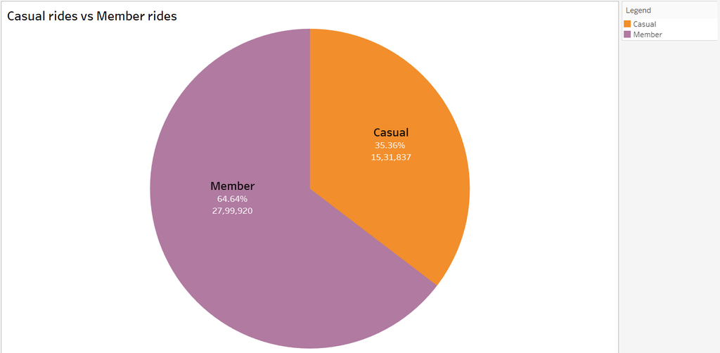

Distribution of rides taken across days of the week and months, offering clear insights into ride frequency patterns over time.

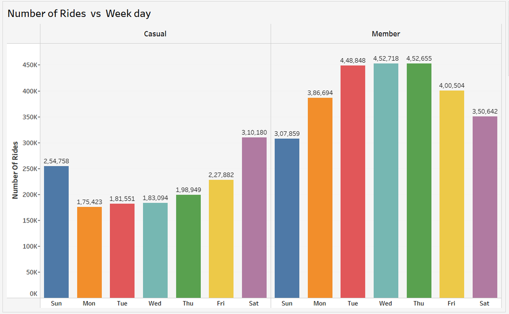

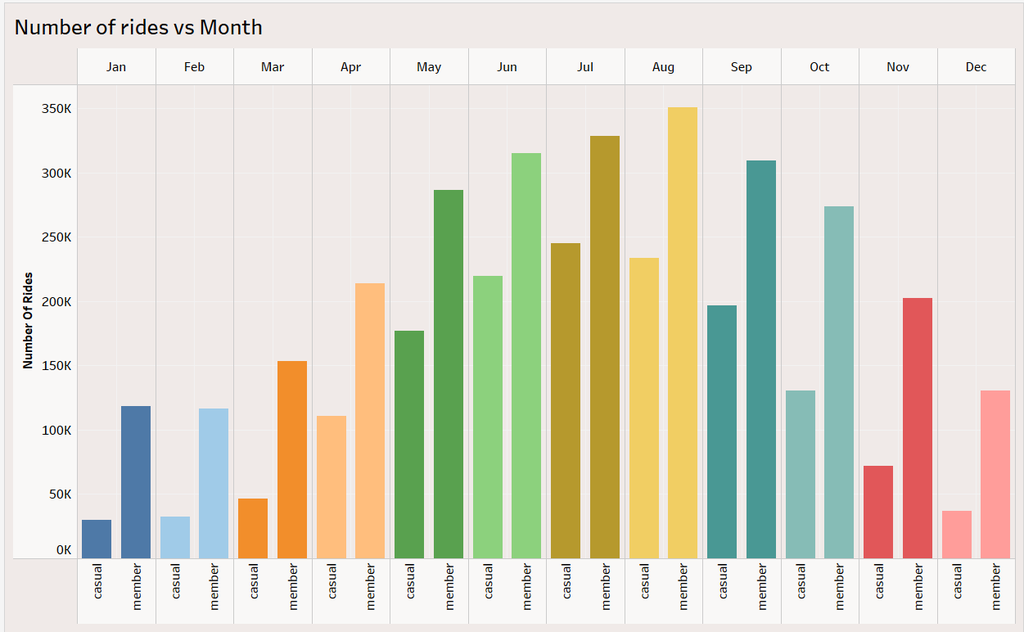

[figure not shown]

[figure not shown]

#### Conclusion:

1. **Marketing Strategy**:
   - Tailor marketing efforts to capitalize on the higher ride frequency of members, possibly through loyalty programs or incentives.
   - Weekend promotions could attract more casual riders, aligning with their peak ride frequency during weekends.
2. **Seasonal Campaigns**:
   - Develop seasonal marketing campaigns, especially during summer when ride demand is at its peak for both rider types.
   - Highlight the benefits of biking during summer months, such as leisurely rides or outdoor activities.
3. **Service Improvement**:
   - Consider enhancing services during peak periods, such as weekends for casual riders, to ensure a positive user experience.
   - For casual riders experiencing longer ride durations, offer amenities or incentives to make their trips more comfortable or enjoyable.
4. **Membership Conversion**:
   - Encourage casual riders to become members by highlighting the convenience and benefits of membership, potentially offering trial memberships or discounts during peak riding seasons.